# Пятый этап индивидуального проекта

Операционные системы

Панина Ж. В.

Российский университет дружбы народов, Москва, Россия

14 мая 2025

# Информация

## Докладчик

- Панина Жанна Валерьевна
- НКАбд-02-24, студ. билет № 1132246710
- студент направления “Компьютерные и информационные науки”
- Российский университет дружбы народов
- 1132246710@pfur.ru
- https://github.com/zvpanina/study_2024-2025_os-intro

# Вводная часть

## Актуальность

В условиях стремительного развития информационных технологий и цифровизации всех сфер жизни создание и поддержка персонального сайта становится важным инструментом профессионального самоопределения, самопрезентации и ведения цифрового портфолио. Особенно актуальным это является для студентов технических направлений, которым важно не только демонстрировать свои проекты, но и развивать навыки работы с веб-технологиями и операционными системами. Добавление записей о персональных проектах, рефлексии за прошедшую неделю и статьи о языках научного программирования позволяет наполнить сайт содержанием, отражающим как учебную, так и исследовательскую деятельность.

## Объект и предмет исследования

### Объект исследования:

Процесс разработки и наполнения персонального сайта на основе статической генерации с использованием системы Hugo

### Предмет исследования:

Технические и содержательные аспекты интеграции научных и информационных компонентов (ссылки, посты, иконки, структура контента) в структуру сайта.

## Цели и задачи

Цель работы - продолжить работу с сайтом, добавить к сайту записи для персональных проектов, а также пост по прошедшей неделе и пост по выбору.

# Задачи

1. Сделать записи для персональных проектов.
2. Сделать пост по прошедшей неделе.
3. Добавить пост на тему по выбору:
- Языки научного программирования.

## Материалы и методы исследования

### Материалы:

- Сайт проекта, созданный с помощью Hugo;
- Контент: записи о персональных проектах, пост о прошедшей неделе, пост о языках научного программирования;
- Markdown-файлы для постов и контента;

### Методы:

- Работа с системой шаблонов Hugo;
- Вёрстка и структурирование контента с использованием Markdown;
- Интеграция внешних ссылок и медиа;
- Метод изучения и обобщения информации о научных языках программирования;
- Тестирование отображения сайта на разных устройствах.

# Выполнение индивидуального проекта

1. В папке /blog/content/project/ создаю папку github.

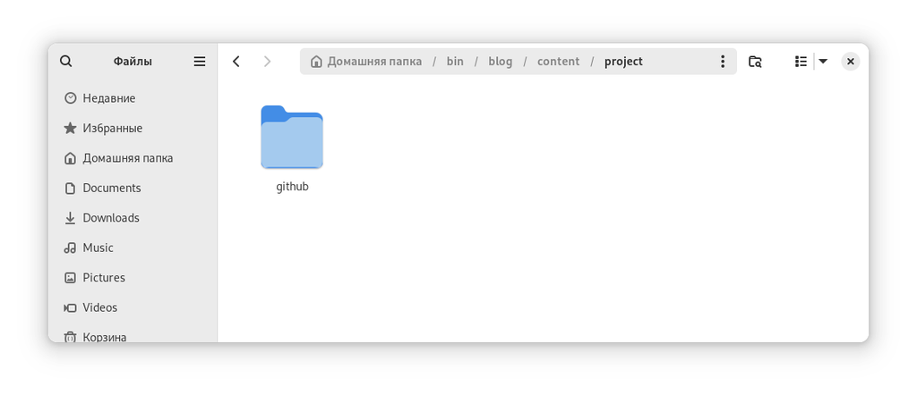

Создание папки github

Делаю запись о персональном проекте (GitHub).

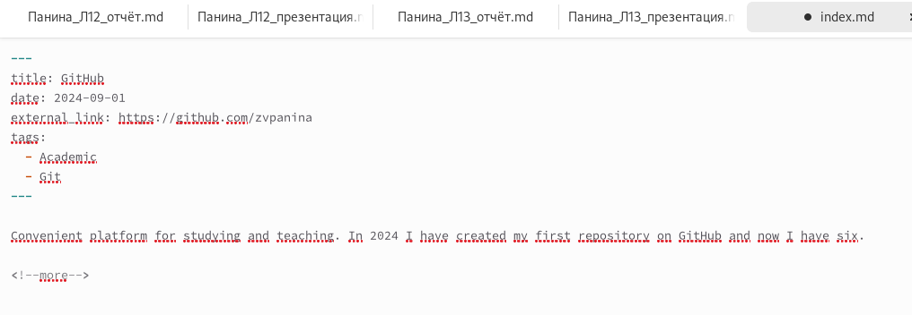

Пост с информацией о странице на GitHub

Добавляю фотографию своего профиля к посту в нужный каталог.

[figure not shown]

Добавление фотографии профиля

2. Начинаю редактировать файл для поста о прошедшей неделе.

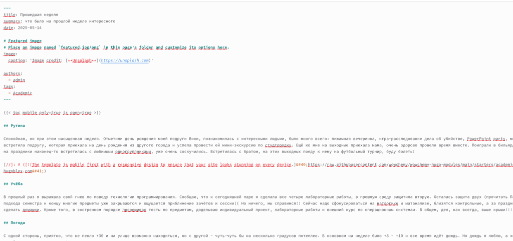

Подготовка поста “Прошедшая неделя”

Добавляю фотографию к посту в нужный каталог.

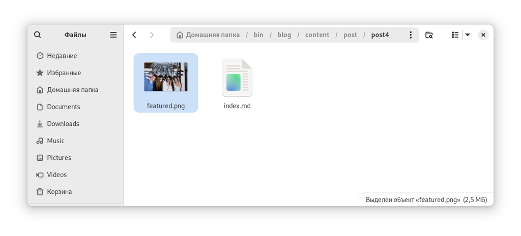

Добавление фотографии, сделанной на прошедшей неделе

3. Начинаю редактировать файл для поста по выбору.

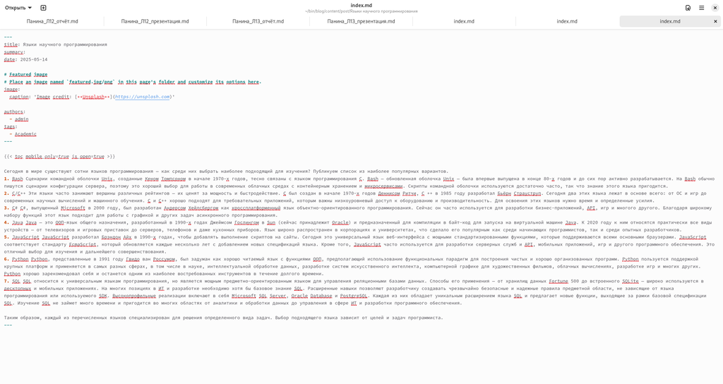

Подготовка поста “Языки научного программирования”

Добавляю фотографию к посту в нужный каталог.

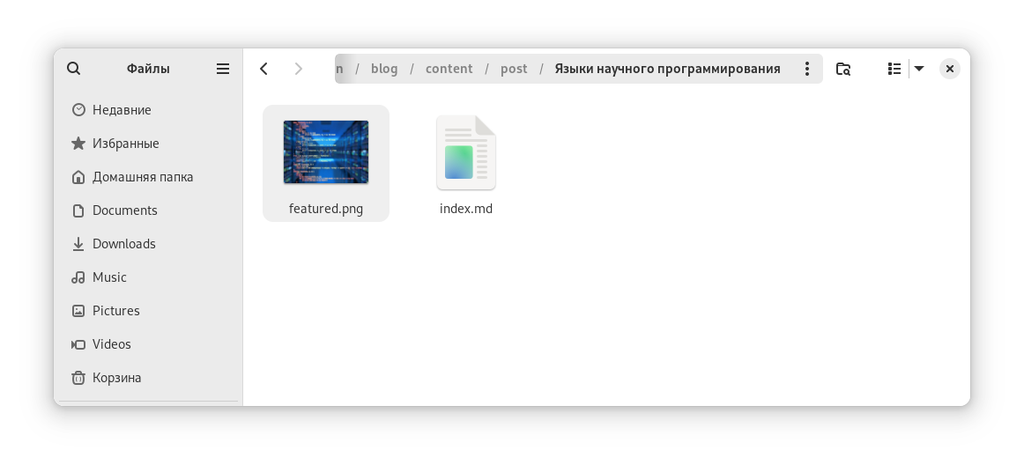

Добавление фотографии с языками программирования

4. Запускаю сайт командой server, чтобы проверить изменения.

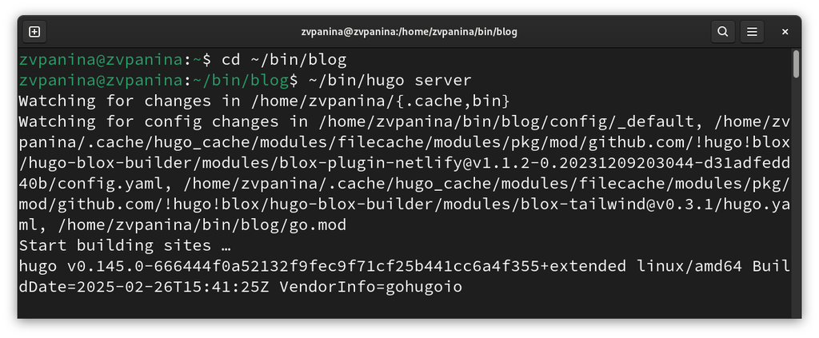

Запуск сайта

Проверяю изменения на сайте. Оба поста выложены, а также появилась запись о проекте.

[figure not shown]

Выложенный пост о языках программирования

[figure not shown]

Выложенный пост о прошедшей неделе

[figure not shown]

Выложенный проект

5. Отправляю изменения на глобальный репозиторий.

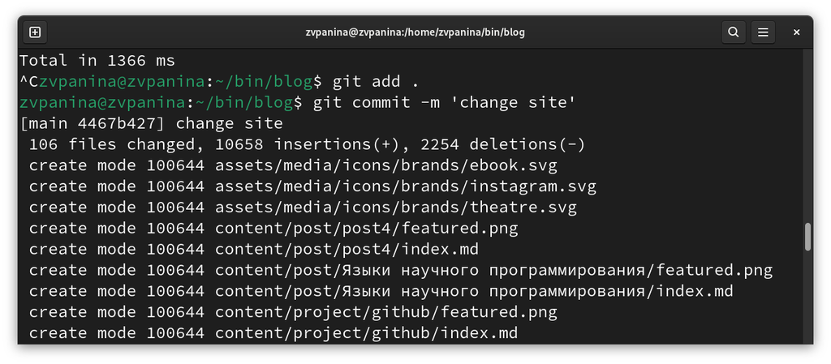

## Результаты

В ходе выполнения пятого этапа индивидуального проекта я продолжила работу с сайтом, добавила к сайту информацию о проектах, а также пост по прошедшей неделе и пост по выбору.